# MEML_HW06

**Machine Learning for Mechanical Engineering**  
**Homework 06**  
**Due Tuesday, 05/05/2020, 09:30 AM**

TA: Taewan Kim  
Instructor: Prof. Seungchul Lee  
http://iai.postech.ac.kr/  
Industrial AI Lab at POSTECH

- For your handwritten solution, scan or take a picture of them.
- For your code, only .ipynb file will be graded.
  - Please write your NAME and student ID on your .ipynb files. ex) TaewanKim_HW06.ipynb
- Please compress all files to make a single .zip file
  - Please write your NAME and student ID on your .zip files. ex) TaewanKim_HW06.zip
  - Submit it to LMS
- Do not submit a printed version of your code. It will not be graded.

# Problem 1

(a) Let $f(x) = \omega^Tx$ be a linear boundary of a binary classifier and $y \in \{-1,1\}$. Explain $y \cdot f(x) \leq 0$ when the classifier is wrong and $y \cdot f(x) > 0$ when the classifier is correct.

(b) Let $\ell \left(f(x), y \right)$ be a loss function. Ideally, the loss function for the classification problem is $u \left(-y \cdot f(x) \right)$ where $u(\cdot)$ is a step function. Explain the meaning of $J = \sum_{i=1}^{N} u \left(-y_i \cdot f(x_i) \right)$.

(c) Explain why the ideal loss function cannot be implemented when we want to use a gradient descent algorithm?

(d) In the logistic regression, we define

$$\sigma(z) = \frac{1}{1 + e^{-z}}$$

Then, show

$$ \frac{d\sigma(z)}{dz} = \sigma(z)(1-\sigma(z))$$

Note: this property is useful in a gradient descent for a parameter learning.

(e) Plot the ideal loss function and the loss function of the logistic regression. Compare the shape of both loss functions and explain why the logistic regression can approximately solve the classification problem.

# Problem 2

We would like to use the SVM to classify digit 0 and digit 1 in the training set.

## Step 1. Load the data

| Data | Data dexcription |
| --- | --- |
| 0 | 1000 images (28×28 pixels) of handwritten digit 0 |
| 1 | 1000 images (28×28 pixels) of handwritten digit 1 |

[Download data](https://www.dropbox.com/s/aokbzv5cy2rbmzy/data.pkl?dl=1)

To read the files in Python, use the following code:

```python
import matplotlib.pyplot as plt
from six.moves import cPickle

data = cPickle.load(open('./data_files/data.pkl', 'rb'))
data0 = data['0']
data1 = data['1']
```

(a) Display the few random images in each class.

```python
## your code here
```

(b) Convert each of the pixels in 28×28 matrix to a binary value.

```python
## your code here
```

## Step 2. Extract features

Now we must select the own ‘features’ from image data to detect digit 0 and digit 1. Two features are recommended

(bias) Include the ones as our bias term.

(feature 1) The total average pixels located at the center of the image (`img[10:20,10:20]`).

(feature 2) The total average pixels over the entire location.

$$\Phi(x) = \begin{bmatrix} 1 \\ \text{feature1}\\ \text{feature2} \end{bmatrix}$$

You should end up with a $2000\times3$ input matrix with the first $1000$ rows correspond to all of the ‘`data0`’ and the second 1000 rows correspond to the two features for all of the given ‘`data1`’. This matrix is matrix $\Phi$ which we learned in a class.

```python
## your code here
```

## Step 3. Define variables

Find a classifier using the support vector machine which is equivalent to solving the following optimization problem:

$$\begin{align*} \text{minimize } & \lVert \omega \rVert_2 + \gamma(1^Tu + 1^Tv)\\\\ \text{subject to }& \\ & X^T \omega + \omega_0 \geq 1 - u\\ & Y^T \omega + \omega_0 \leq - (1-v)\\ & u \geq 0\\ & v \geq 0 \end{align*}$$

Here, $X$ and $Y$ are $1000\times3$ matrix for each class. You can divide the above matrix $\Phi$ into two parts to reuse it.

```python
## your code here
```

## Step 4. CVX

Run CVX to find $\omega$.

```python
## your code here
```

## Step 5. Plot the result

Now you have an optimal $\omega$ . Plot a decision boundary. Note that our decision boundary is defined as follows:

$$ \omega_1 x_1 + \omega_2 x_2 + \omega_3 = 0$$

The expected graph is:

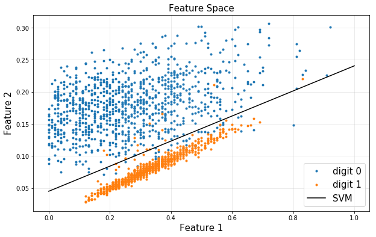

```python
## your code here
```

# Problem 3

[Classification with more than two classes]

We learned about a binary classification in class. However, we have to deal with multi-class classifications for some cases. I provide three groups of data in the following python code. Create your own algorithms in python to find linear classification surfaces and classes that each data belongs to using the logistic regression classifier.

(hint: use binary classification algorithms and extend it to multi-class classification problems)

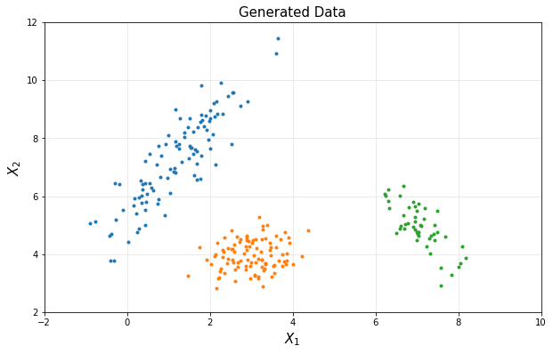

```python
import numpy as np
import matplotlib.pyplot as plt

## generate three simulated clusters

mu1 = np.array([1, 7])
SIGMA1 = 0.8*np.array([[1, 1.5],
                       [1.5, 3]])
X1 = np.random.multivariate_normal(mu1, SIGMA1, 100)

mu2 = np.array([3, 4])
SIGMA2 = 0.3*np.array([[1, 0],
                       [0, 1]])
X2 = np.random.multivariate_normal(mu2, SIGMA2, 100)

mu3 = np.array([7, 5])
SIGMA3 = 0.3*np.array([[1, -1],
                       [-1, 2]])
X3 = np.random.multivariate_normal(mu3, SIGMA3, 50)

plt.figure(figsize=(10, 6))
plt.title('Generated Data', fontsize=15)
plt.plot(X1[:,0], X1[:,1], '.')
plt.plot(X2[:,0], X2[:,1], '.')
plt.plot(X3[:,0], X3[:,1], '.')
plt.xlabel('$X_1$', fontsize=15)
plt.ylabel('$X_2$', fontsize=15)
plt.grid(alpha=0.3)
plt.axis([-2, 10, 2, 12])
plt.show()
```

```python
## your code here
```